# PML_Project

Jumbo Panda

2/26/2017

# Practical Machine Learning Project

Using devices such as Jawbone Up, Nike FuelBand, and Fitbit it is now possible to collect a large amount of data about personal activity relatively inexpensively. These type of devices are part of the quantified self movement – a group of enthusiasts who take measurements about themselves regularly to improve their health, to find patterns in their behavior, or because they are tech geeks.

In this project, my goal will be to use data from accelerometers on the belt, forearm, arm, and dumbell of 6 participants to predict how well a certain exercise was done on a scale of A to E. They were asked to perform barbell lifts correctly and incorrectly in 5 different ways.

# Load & Clean Data

Load Libraries:

```r
library(caret); library(rattle); library(rpart); library(rpart.plot)
library(randomForest); library(repmis)
```

Read in data from URLs provided. More information on data is here: http://groupware.les.inf.puc-rio.br/har. As data is loaded, various formats of missing data are coded as NA.

# Split training data into training and validation.

Data is split into two parts: train and test. Below, the train data is split further to faciliate validation testing.

```r
set.seed(1234)
inTrain = createDataPartition(train$classe, p = .7)[[1]]
training = train[inTrain,]
validating = train[-inTrain,]
```

# Build Predictive Models

Build cross-validation parameters - limiting to 3-Fold Cross Validataion to save processing time here.

```r
control <- trainControl(method = "cv", number = 3)
```

## RPART Model

Becaue our dependent variable is categorical (A through E) we cannot use linear models. The first attempt at a model will be to use a rpart model using the above defined CV parameters:

```r
fit_rpart <- train(classe ~ ., data = training, method = "rpart",
                   trControl = control)
print(fit_rpart, digits = 4)
```

```
## CART
##
## 13737 samples
##    52 predictor
##     5 classes: 'A', 'B', 'C', 'D', 'E'
##
## No pre-processing
## Resampling: Cross-Validated (3 fold)
## Summary of sample sizes: 9157, 9157, 9160
## Resampling results across tuning parameters:
##
##   cp       Accuracy  Kappa
##   0.03550  0.5358    0.40772
##   0.06093  0.3683    0.12785
##   0.11738  0.3116    0.04139
##
## Accuracy was used to select the optimal model using  the largest value.
## The final value used for the model was cp = 0.0355.
```

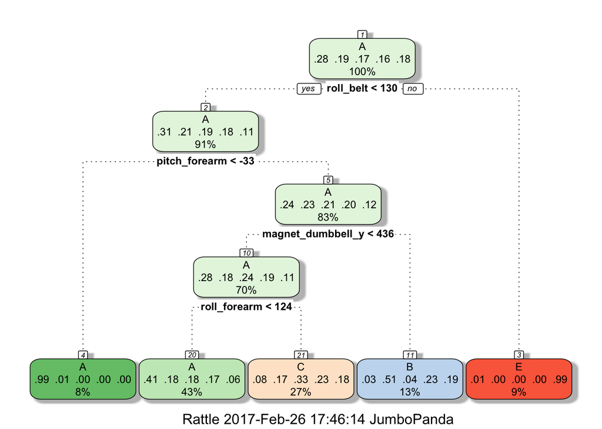

```r
fancyRpartPlot(fit_rpart$finalModel)
```

We use the prediction object to predict on the validation data set:

```r
# predict outcomes using validation set
predict_rpart <- predict(fit_rpart, validating)
```

However, the accuracy is low.

```r
# Show prediction result
(conf_rpart <- confusionMatrix(validating$classe, predict_rpart))
```

```
## Confusion Matrix and Statistics
##
##           Reference
## Prediction    A    B    C    D    E
##          A 1530   35  105    0    4
##          B  486  379  274    0    0
##          C  493   31  502    0    0
##          D  452  164  348    0    0
##          E  168  145  302    0  467
##
## Overall Statistics
##
##                Accuracy : 0.489
##                  95% CI : (0.4762, 0.5019)
##     No Information Rate : 0.5317
##     P-Value [Acc > NIR] : 1
##
##                   Kappa : 0.3311
##  Mcnemar's Test P-Value : NA
##
## Statistics by Class:
##
##                      Class: A Class: B Class: C Class: D Class: E
## Sensitivity            0.4890   0.5027   0.3279       NA  0.99151
## Specificity            0.9478   0.8519   0.8797   0.8362  0.88641
## Pos Pred Value         0.9140   0.3327   0.4893       NA  0.43161
## Neg Pred Value         0.6203   0.9210   0.7882       NA  0.99917
## Prevalence             0.5317   0.1281   0.2602   0.0000  0.08003
## Detection Rate         0.2600   0.0644   0.0853   0.0000  0.07935
## Detection Prevalence   0.2845   0.1935   0.1743   0.1638  0.18386
## Balanced Accuracy      0.7184   0.6773   0.6038       NA  0.93896
```

Overall accuracy is:

```r
(accuracy_rpart <- conf_rpart$overall[1])
```

```
##  Accuracy
## 0.4890399
```

## Random Forest Model

In an effort to improve accuracy a Random Forest Model is generated:

```r
fit_rf <- train(classe ~ ., data = training, method = "rf",
                trControl = control)
print(fit_rf, digits = 3)
```

```
## Random Forest
##
## 13737 samples
##    52 predictor
##     5 classes: 'A', 'B', 'C', 'D', 'E'
##
## No pre-processing
## Resampling: Cross-Validated (3 fold)
## Summary of sample sizes: 9159, 9157, 9158
## Resampling results across tuning parameters:
##
##   mtry  Accuracy  Kappa
##    2    0.989     0.986
##   27    0.989     0.986
##   52    0.986     0.982
##
## Accuracy was used to select the optimal model using  the largest value.
## The final value used for the model was mtry = 27.
```

Again we use the Random Forest prediction object to predict on the validation data set. This RF model is much better at predicting the Classe variable.

```r
# predict outcomes using validation set
predict_rf <- predict(fit_rf, validating)
# Show prediction result
(conf_rf <- confusionMatrix(validating$classe, predict_rf))
```

```
## Confusion Matrix and Statistics
##
##           Reference
## Prediction    A    B    C    D    E
##          A 1674    0    0    0    0
##          B   10 1128    1    0    0
##          C    0    5 1017    4    0
##          D    0    1    6  955    2
##          E    0    1    2    3 1076
##
## Overall Statistics
##
##                Accuracy : 0.9941
##                  95% CI : (0.9917, 0.9959)
##     No Information Rate : 0.2862
##     P-Value [Acc > NIR] : < 2.2e-16
##
##                   Kappa : 0.9925
##  Mcnemar's Test P-Value : NA
##
## Statistics by Class:
##
##                      Class: A Class: B Class: C Class: D Class: E
## Sensitivity            0.9941   0.9938   0.9912   0.9927   0.9981
## Specificity            1.0000   0.9977   0.9981   0.9982   0.9988
## Pos Pred Value         1.0000   0.9903   0.9912   0.9907   0.9945
## Neg Pred Value         0.9976   0.9985   0.9981   0.9986   0.9996
## Prevalence             0.2862   0.1929   0.1743   0.1635   0.1832
## Detection Rate         0.2845   0.1917   0.1728   0.1623   0.1828
## Detection Prevalence   0.2845   0.1935   0.1743   0.1638   0.1839
## Balanced Accuracy      0.9970   0.9958   0.9947   0.9954   0.9984
```

The RF Overall Accuracy is over 99% so this model is chosen as the final model:

```r
# Predict model on Test data
(accuracy_rf <- conf_rf$overall[1])
```

```
##  Accuracy
## 0.9940527
```

## Make Final Prediction

To complete the project we apply the superior RF prediction object on the Test data set to predict the 20 outcomes:

```r
(predict(fit_rf, test))
```

```
##  [1] B A B A A E D B A A B C B A E E A B B B
## Levels: A B C D E
```